# Why Exploratory Data Analysis of Coffee Shop Sales Trends Project?

The project *Exploratory Data Analysis of Coffee Shop Sales Trends* was undertaken to address the following:

- **Data-Driven Decision Making**: Help coffee shop owners understand sales trends and customer preferences to improve business strategies.
- **Customer Insights**: Analyze transactional data to uncover patterns in customer behavior, such as peak sales times and preferred products.
- **Performance Optimization**: Provide actionable insights for optimizing inventory, staffing, and promotional efforts.
- **Scalable Framework**: Build a reusable data analysis framework that can be adapted to other retail datasets.

### Impact of this project?

- Enabled better resource allocation by identifying high-performing stores and time slots.
- Supported marketing strategies by revealing top-selling products and revenue patterns.
- Established a data-driven approach for making business decisions in competitive retail environments.

Below is the detailed steps of *Exploratory Data Analysis of Coffee Shop Sales Trends* project:

# Import Library

```python
import pandas as pd
import seaborn as sns
from sklearn.svm import SVC
import matplotlib.pyplot as plt
from sklearn.naive_bayes import GaussianNB
from sklearn.tree import DecisionTreeClassifier
from sklearn.linear_model import LogisticRegression
from mlxtend.preprocessing import TransactionEncoder
from sklearn.model_selection import train_test_split
from sklearn.preprocessing import LabelEncoder, StandardScaler
from mlxtend.frequent_patterns import apriori, association_rules
from sklearn.metrics import accuracy_score, confusion_matrix, classification_report
from sklearn.ensemble import RandomForestClassifier, BaggingClassifier, VotingClassifier
```

# Load the dataset

```python
data = pd.read_csv('/content/Coffee_Shop_Sales.csv')
data2 = data
```

```python
data.head()
```

|  | transaction_id | transaction_date | transaction_time | transaction_qty | store_id | store_location | product_id | unit_price | product_category | product_type | product_detail |
| --- | --- | --- | --- | --- | --- | --- | --- | --- | --- | --- | --- |
| 0 | 1 | 1/1/2023 | 7:06:11 | 2 | 5 | Lower Manhattan | 32 | 3.0 | Coffee | Gourmet brewed coffee | Ethiopia Rg |
| 1 | 2 | 1/1/2023 | 7:08:56 | 2 | 5 | Lower Manhattan | 57 | 3.1 | Tea | Brewed Chai tea | Spicy Eye Opener Chai Lg |
| 2 | 3 | 1/1/2023 | 7:14:04 | 2 | 5 | Lower Manhattan | 59 | 4.5 | Drinking Chocolate | Hot chocolate | Dark chocolate Lg |
| 3 | 4 | 1/1/2023 | 7:20:24 | 1 | 5 | Lower Manhattan | 22 | 2.0 | Coffee | Drip coffee | Our Old Time Diner Blend Sm |
| 4 | 5 | 1/1/2023 | 7:22:41 | 2 | 5 | Lower Manhattan | 57 | 3.1 | Tea | Brewed Chai tea | Spicy Eye Opener Chai Lg |

# Check data types and make sure they're correct

```python
print(data.dtypes)
```

```
transaction_id        int64
transaction_date     object
transaction_time     object
transaction_qty       int64
store_id              int64
store_location       object
product_id            int64
unit_price          float64
product_category     object
product_type         object
product_detail       object
dtype: object
```

# Convert transaction_date and transaction_time to datetime objects

```python
data['transaction_date'] = pd.to_datetime(data['transaction_date'], format='%m/%d/%Y')
data['transaction_time'] = pd.to_datetime(data['transaction_time'], format='%H:%M:%S').dt.time
```

```python
data.head()
```

|  | transaction_id | transaction_date | transaction_time | transaction_qty | store_id | store_location | product_id | unit_price | product_category | product_type | product_detail |
| --- | --- | --- | --- | --- | --- | --- | --- | --- | --- | --- | --- |
| 0 | 1 | 2023-01-01 | 07:06:11 | 2 | 5 | Lower Manhattan | 32 | 3.0 | Coffee | Gourmet brewed coffee | Ethiopia Rg |
| 1 | 2 | 2023-01-01 | 07:08:56 | 2 | 5 | Lower Manhattan | 57 | 3.1 | Tea | Brewed Chai tea | Spicy Eye Opener Chai Lg |
| 2 | 3 | 2023-01-01 | 07:14:04 | 2 | 5 | Lower Manhattan | 59 | 4.5 | Drinking Chocolate | Hot chocolate | Dark chocolate Lg |
| 3 | 4 | 2023-01-01 | 07:20:24 | 1 | 5 | Lower Manhattan | 22 | 2.0 | Coffee | Drip coffee | Our Old Time Diner Blend Sm |
| 4 | 5 | 2023-01-01 | 07:22:41 | 2 | 5 | Lower Manhattan | 57 | 3.1 | Tea | Brewed Chai tea | Spicy Eye Opener Chai Lg |

# Check for duplicates and missing values

```python
duplicates = data.duplicated().sum()
missing_values = data.isnull().sum()

print(f"Number of duplicate rows: {duplicates}")
print("Missing values per column:\n", missing_values)
```

```
Number of duplicate rows: 0
Missing values per column:
 transaction_id      0
transaction_date    0
transaction_time    0
transaction_qty     0
store_id            0
store_location      0
product_id          0
unit_price          0
product_category    0
product_type        0
product_detail      0
dtype: int64
```

# Data Preprocessing

### Dropping unnecessary columns

```python
important_features = ['transaction_qty', 'store_id', 'unit_price', 'product_category']
data = data[important_features]
data.head()
```

|  | transaction_qty | store_id | unit_price | product_category |
| --- | --- | --- | --- | --- |
| 0 | 2 | 5 | 3.0 | Coffee |
| 1 | 2 | 5 | 3.1 | Tea |
| 2 | 2 | 5 | 4.5 | Drinking Chocolate |
| 3 | 1 | 5 | 2.0 | Coffee |
| 4 | 2 | 5 | 3.1 | Tea |

### Encoding categorical columns

```python
label_encoders = {}
for column in ['product_category']:
    le = LabelEncoder()
    data[column] = le.fit_transform(data[column])
    label_encoders[column] = le

data3 = data
data.head()
data3.isnull().sum()
```

|  | 0 |
| --- | --- |
| transaction_qty | 0 |
| store_id | 0 |
| unit_price | 0 |
| product_category | 0 |

**dtype:** int64

# Create a revenue column

```python
data = data2
data['transaction_revenue'] = data['transaction_qty'] * data['unit_price']
```

# Exploratory Data Analysis (EDA)

# Sales trends over time

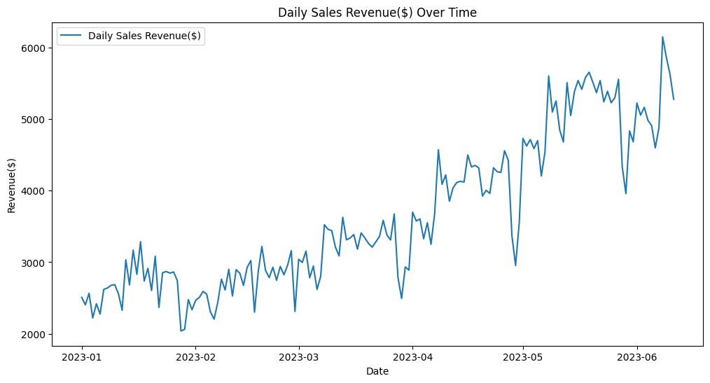

```python
daily_sales = data.groupby('transaction_date')['transaction_revenue'].sum()
plt.figure(figsize=(12, 6))
plt.plot(daily_sales.index, daily_sales.values, label='Daily Sales Revenue($)')
plt.xlabel('Date')
plt.ylabel('Revenue($)')
plt.title('Daily Sales Revenue($) Over Time')
plt.legend()
plt.show()
```

# Product Performance

```python
product_sales = data.groupby(['product_category', 'product_type'])['transaction_revenue'].sum().sort_values(ascending=False)
print("Top-selling products by category and type:\n", product_sales)
```

```
Top-selling products by category and type:
 product_category    product_type
Coffee              Barista Espresso         77242.45
Tea                 Brewed Chai tea          65785.10
Drinking Chocolate  Hot chocolate            61517.00
Coffee              Gourmet brewed coffee    59166.60
Tea                 Brewed Black tea         40949.00
                    Brewed herbal tea        40292.50
Coffee              Premium brewed coffee    33134.35
                    Organic brewed coffee    31958.20
Bakery              Scone                    31126.42
Coffee              Drip coffee              27029.50
Bakery              Pastry                   21816.74
Tea                 Brewed Green tea         20468.00
Bakery              Biscotti                 16802.90
Coffee beans        Premium Beans            11114.25
                    Organic Beans             7075.50
Branded             Housewares                6107.00
Coffee beans        Gourmet Beans             5583.00
Flavours            Regular syrup             4953.60
Branded             Clothing                  4801.00
Coffee beans        Espresso Beans            4591.75
Loose Tea           Chai tea                  3491.90
Coffee beans        House blend Beans         2628.00
Packaged Chocolate  Drinking Chocolate        2293.45
Loose Tea           Black tea                 2246.45
                    Herbal tea                2237.50
Flavours            Sugar free syrup          1898.40
Packaged Chocolate  Organic Chocolate         1406.00
Loose Tea           Green tea                 1202.50
Coffee beans        Green beans               1160.00
Name: transaction_revenue, dtype: float64
```

# Store Analysis

```python
store_sales = data.groupby(['store_location', 'store_id'])['transaction_revenue'].sum().sort_values(ascending=False)
print("Top-performing stores:\n", store_sales)
```

```
Top-performing stores:
 store_location   store_id
Hell's Kitchen   8.0         199662.63
Astoria          3.0         196444.41
Lower Manhattan  5.0         193972.02
Name: transaction_revenue, dtype: float64
```

# Time-of-Day Analysis

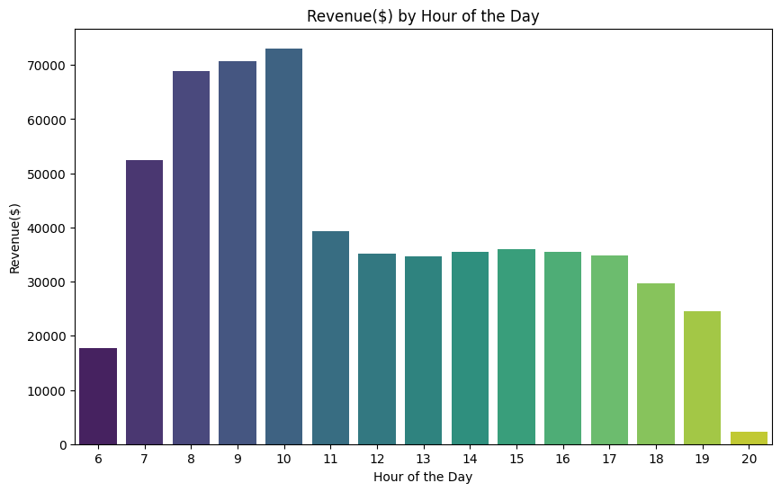

```python
data['transaction_hour'] = pd.to_datetime(data['transaction_time'], format='%H:%M:%S').dt.hour
hourly_sales = data.groupby('transaction_hour')['transaction_revenue'].sum()
plt.figure(figsize=(10, 6))
sns.barplot(x=hourly_sales.index, y=hourly_sales.values, palette="viridis")
plt.xlabel('Hour of the Day')
plt.ylabel('Revenue($)')
plt.title('Revenue($) by Hour of the Day')
plt.show()
```

# Overall Revenue Analysis

```python
total_revenue = data['transaction_revenue'].sum()
print(f"Total revenue for the period: ${total_revenue:.2f}")
```

```
Total revenue for the period: $590079.06
```

# Customer Behavior Analysis

```python
data['transaction_date'] = pd.to_datetime(data['transaction_date'])
data['day_of_week'] = data['transaction_date'].dt.day_name()
data['transaction_hour'] = pd.to_datetime(data['transaction_time'], format='%H:%M:%S').dt.hour
```

### Sales by Day of the Week

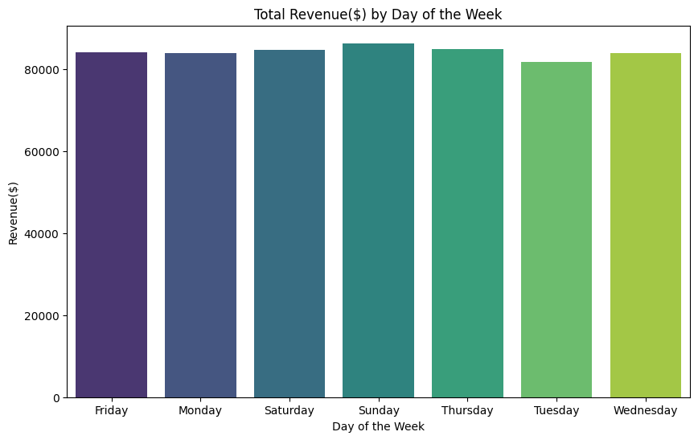

```python
sales_by_day = data.groupby('day_of_week')['transaction_revenue'].sum()
plt.figure(figsize=(10, 6))
sns.barplot(x=sales_by_day.index, y=sales_by_day.values, palette='viridis')
plt.title('Total Revenue($) by Day of the Week')
plt.xlabel('Day of the Week')
plt.ylabel('Revenue($)')
plt.show()
```

### Sales by Hour of the Day

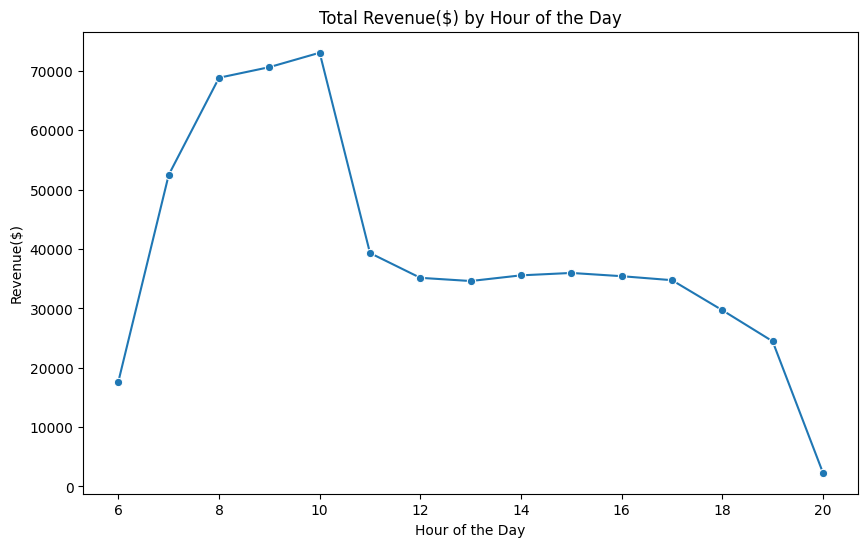

```python
sales_by_hour = data.groupby('transaction_hour')['transaction_revenue'].sum()
plt.figure(figsize=(10, 6))
sns.lineplot(x=sales_by_hour.index, y=sales_by_hour.values, marker='o')
plt.title('Total Revenue($) by Hour of the Day')
plt.xlabel('Hour of the Day')
plt.ylabel('Revenue($)')
plt.show()
```

# Product Performance Analysis

### Total revenue by product category

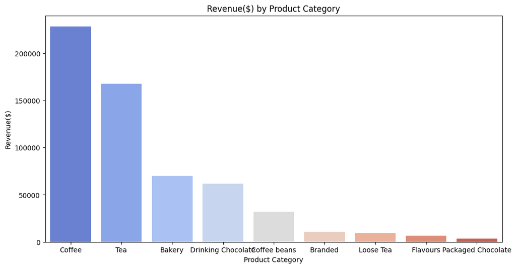

```python
product_sales = data.groupby('product_category')['transaction_revenue'].sum().sort_values(ascending=False)
plt.figure(figsize=(12, 6))
sns.barplot(x=product_sales.index, y=product_sales.values, palette="coolwarm")
plt.title('Revenue($) by Product Category')
plt.xlabel('Product Category')
plt.ylabel('Revenue($)')
plt.show()
```

### Detailed analysis of top-performing product types

```python
top_products = data.groupby(['product_category', 'product_type'])['transaction_revenue'].sum()
top_products = top_products.sort_values(ascending=False).head(10).reset_index()
print("Top-performing products:\n", top_products.head(10))
```

```
Top-performing products:
      product_category           product_type  transaction_revenue
0              Coffee       Barista Espresso             77242.45
1                 Tea        Brewed Chai tea             65785.10
2  Drinking Chocolate          Hot chocolate             61517.00
3              Coffee  Gourmet brewed coffee             59166.60
4                 Tea       Brewed Black tea             40949.00
5                 Tea      Brewed herbal tea             40292.50
6              Coffee  Premium brewed coffee             33134.35
7              Coffee  Organic brewed coffee             31958.20
8              Bakery                  Scone             31126.42
9              Coffee            Drip coffee             27029.50
```

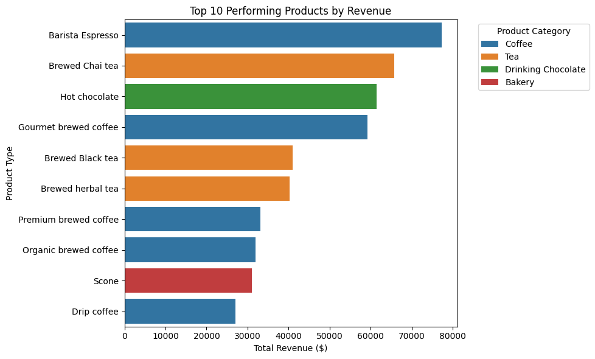

```python
# Plotting with Seaborn
plt.figure(figsize=(10, 6))
sns.barplot(
    data=top_products,
    x='transaction_revenue',
    y='product_type',
    hue='product_category',
    dodge=False
)

# Adding plot labels and title
plt.xlabel('Total Revenue ($)')
plt.ylabel('Product Type')
plt.title('Top 10 Performing Products by Revenue')
plt.legend(title='Product Category', bbox_to_anchor=(1.05, 1), loc='upper left')
plt.tight_layout()
plt.show()
```

# Store Performance Analysis

### Total revenue by store

```python
store_revenue = data.groupby(['store_location', 'store_id'])['transaction_revenue'].sum().sort_values(ascending=False)
```

### Top-performing stores

```python
print("Top-performing stores:\n", store_revenue.head(5))
```

```
Top-performing stores:
 store_location   store_id
Hell's Kitchen   8.0         199662.63
Astoria          3.0         196444.41
Lower Manhattan  5.0         193972.02
Name: transaction_revenue, dtype: float64
```

[figure not shown]

```python
top_stores = data.sort_values(by='transaction_revenue', ascending=False)

# Plotting with Seaborn
plt.figure(figsize=(10, 6))
sns.barplot(
    data=top_stores,
    x='transaction_revenue',
    y='store_location',
    palette='viridis'
)

# Adding plot labels and title
plt.xlabel('Total Revenue ($)')
plt.ylabel('Store Location')
plt.title('Top 5 Performing Stores by Revenue')
plt.tight_layout()
plt.show()
```

# Revenue and Transaction Analysis

### Average revenue per transaction

```python
avg_revenue_per_transaction = data['transaction_revenue'].mean()
print(f"Average revenue per transaction: ${avg_revenue_per_transaction:.2f}")
```

```
Average revenue per transaction: $4.67
```

### Transaction revenue distribution

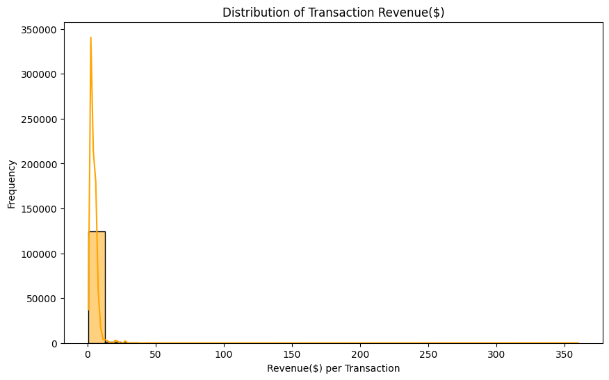

```python
plt.figure(figsize=(10, 6))
sns.histplot(data['transaction_revenue'], bins=30, kde=True, color='orange')
plt.title('Distribution of Transaction Revenue($)')
plt.xlabel('Revenue($) per Transaction')
plt.ylabel('Frequency')
plt.show()
```

# Time-Based Trends (Monthly and Quarterly Sales Trends)

### Extracting month and quarter

```python
data['month'] = data['transaction_date'].dt.month
data['quarter'] = data['transaction_date'].dt.quarter
```

### Monthly revenue trend

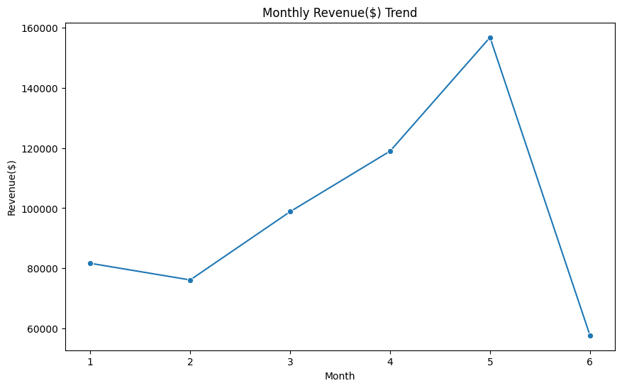

```python
monthly_revenue = data.groupby('month')['transaction_revenue'].sum()
plt.figure(figsize=(10, 6))
sns.lineplot(x=monthly_revenue.index, y=monthly_revenue.values, marker='o')
plt.title('Monthly Revenue($) Trend')
plt.xlabel('Month')
plt.ylabel('Revenue($)')
plt.show()
```

### Quarterly revenue trend

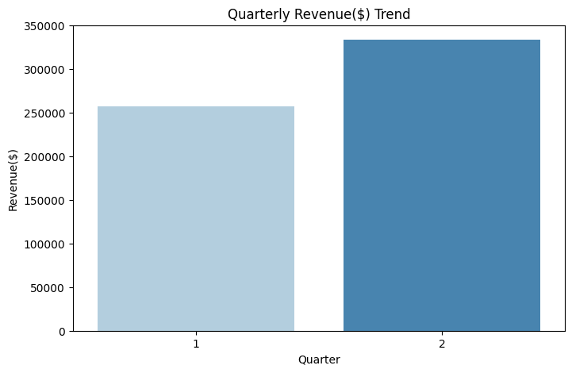

```python
quarterly_revenue = data.groupby('quarter')['transaction_revenue'].sum()
plt.figure(figsize=(8, 5))
sns.barplot(x=quarterly_revenue.index, y=quarterly_revenue.values, palette="Blues")
plt.title('Quarterly Revenue($) Trend')
plt.xlabel('Quarter')
plt.ylabel('Revenue($)')
plt.show()
```

# Product Detail-Level Analysis

### Revenue by product details

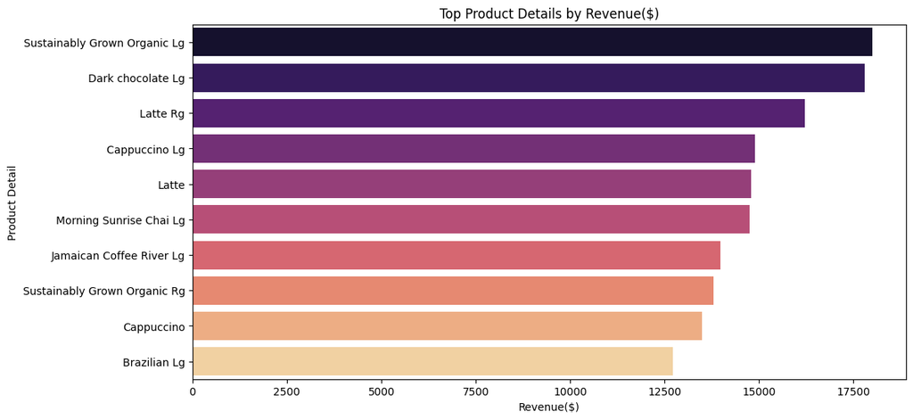

```
Top product details:
 product_detail
Sustainably Grown Organic Lg    17993.00
Dark chocolate Lg               17793.00
Latte Rg                        16205.25
Cappuccino Lg                   14900.50
Latte                           14790.00
Morning Sunrise Chai Lg         14748.00
Jamaican Coffee River Lg        13987.50
Sustainably Grown Organic Rg    13792.50
Cappuccino                      13492.50
Brazilian Lg                    12712.00
Name: transaction_revenue, dtype: float64
```

```python
product_detail_sales = data.groupby('product_detail')['transaction_revenue'].sum().sort_values(ascending=False)
top_product_details = product_detail_sales.head(10)

plt.figure(figsize=(12, 6))
sns.barplot(x=top_product_details.values, y=top_product_details.index, palette="magma")
plt.title('Top Product Details by Revenue($)')
plt.xlabel('Revenue($)')
plt.ylabel('Product Detail')
plt.show()

print("Top product details:\n", top_product_details)
```

# Relational Plot (relplot)

### Revenue by Quantity Purchased

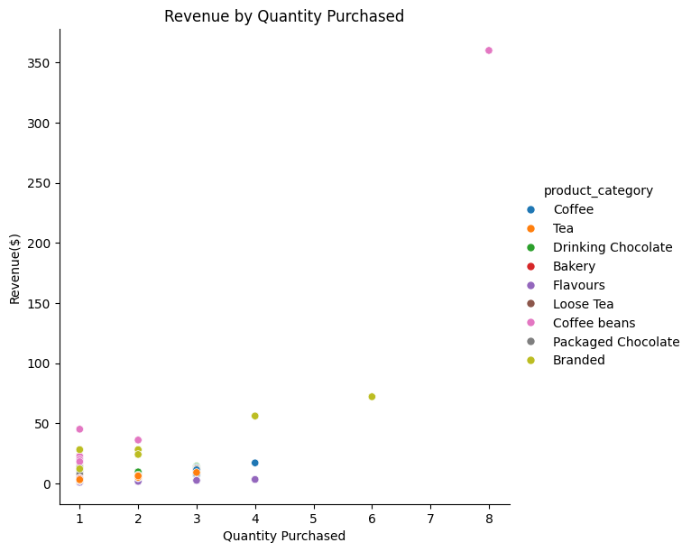

```python
# Assuming 'transaction_revenue' is calculated as transaction_qty * unit_price in the dataset
sns.relplot(x='transaction_qty', y='transaction_revenue', data=data, kind='scatter', hue='product_category', height=6)
plt.title('Revenue by Quantity Purchased')
plt.xlabel('Quantity Purchased')
plt.ylabel('Revenue($)')
plt.show()
```

# Distribution Plot (displot)

### Distribution of Unit Prices by Product Category

[figure not shown]

```python
sns.displot(data, x='unit_price', hue='product_category', kind='kde', height=6, aspect=1.5, fill=True)
plt.title('Distribution of Unit Prices by Product Category')
plt.xlabel('Unit Price($)')
plt.ylabel('Density')
plt.show()
```

# Categorical Plot (catplot)

### Average Revenue per Product Category

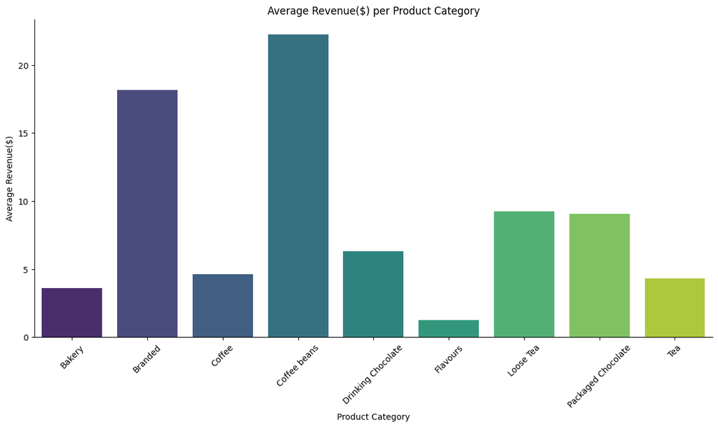

```python
# Calculating average revenue by product category
avg_revenue_by_category = data.groupby('product_category')['transaction_revenue'].mean().reset_index()

sns.catplot(x='product_category', y='transaction_revenue', data=avg_revenue_by_category, kind='bar', height=6, aspect=2, palette="viridis")
plt.title('Average Revenue($) per Product Category')
plt.xlabel('Product Category')
plt.ylabel('Average Revenue($)')
plt.xticks(rotation=45)
plt.show()
```

### Quantity Purchased by Store Location

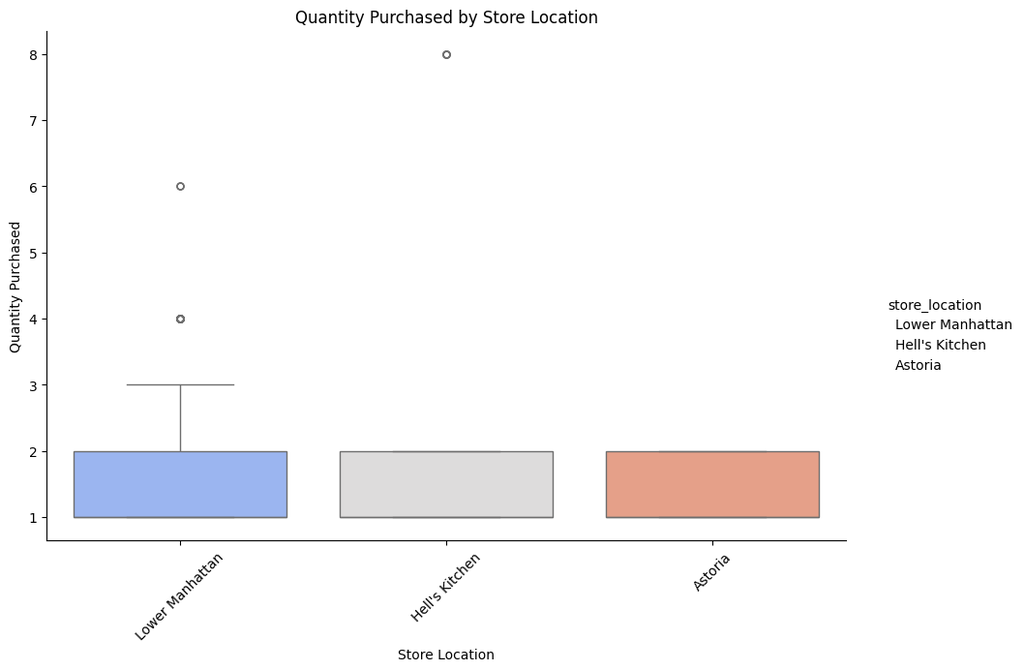

```python
sns.catplot(x='store_location', y='transaction_qty', data=data, kind='box', height=6, aspect=1.5, palette="coolwarm")
plt.title('Quantity Purchased by Store Location')
plt.xlabel('Store Location')
plt.ylabel('Quantity Purchased')
plt.xticks(rotation=45)
plt.show()
```

# Pair plot

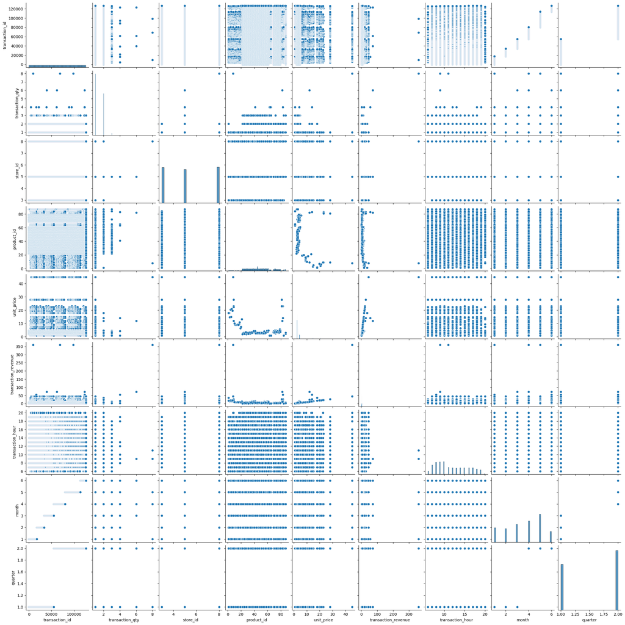

```python
sns.pairplot(data)
```

# Applying Different Data Mining Models

### Apriori Algorithm to Find out Frequent Itemsets and Association Rules

### Steps that needs to follow to apply the apriori algorithm and association rules:

#### Step 1: Transform data into transactional format

#### Each transaction should represent items bought together.

#### Assuming 'transaction_id' groups items bought in one transaction and 'product_category' represents items.

#### Create a one-hot encoded dataframe for Apriori

```python
data = pd.read_csv("/content/Coffee_Shop_Sales.csv")

transactions = data.groupby('transaction_id')['product_category'].apply(list)

te = TransactionEncoder()
te_ary = te.fit(transactions).transform(transactions)
onehot = pd.DataFrame(te_ary, columns=te.columns_)

onehot.head()
```

|  | Bakery | Branded | Coffee | Coffee beans | Drinking Chocolate | Flavours | Loose Tea | Packaged Chocolate | Tea |
| --- | --- | --- | --- | --- | --- | --- | --- | --- | --- |
| 0 | False | False | True | False | False | False | False | False | False |
| 1 | False | False | False | False | False | False | False | False | True |
| 2 | False | False | False | False | True | False | False | False | False |
| 3 | False | False | True | False | False | False | False | False | False |
| 4 | False | False | False | False | False | False | False | False | True |

#### Step 2: Apply Apriori Algorithm

#### Define minimum support threshold (e.g., 0.01 = 1% of transactions)

#### Display frequent itemsets

```python
frequent_itemsets = apriori(onehot, min_support=0.01, use_colnames=True)

print("Frequent Itemsets:")
print(frequent_itemsets)
```

```
Frequent Itemsets:
    support              itemsets
0  0.152874              (Bakery)
1  0.391749              (Coffee)
2  0.011756        (Coffee beans)
3  0.076907  (Drinking Chocolate)
4  0.045535            (Flavours)
5  0.304790                 (Tea)
```

#### Display association rules

```python
rules = association_rules(frequent_itemsets, num_itemsets= len(frequent_itemsets), metric="confidence", min_threshold=0.3)  # Confidence threshold = 30%
print("\nAssociation Rules:")
print(rules if not rules.empty else "No rules found. Try adjusting thresholds.")
```

```
Association Rules:
No rules found. Try adjusting thresholds.
```

#### Step 4: Save the results

#### Save frequent itemsets and rules to CSV files for further analysis

```python
frequent_itemsets.to_csv('frequent_itemsets.csv', index=False)
rules.to_csv('association_rules.csv', index=False)

print("\nFrequent itemsets and association rules have been saved as CSV files.")
```

```
Frequent itemsets and association rules have been saved as CSV files.
```

# Splitting the dataset

### Splitting the dataset into features and target variable

```python
data = data3
X = data.drop('transaction_qty', axis=1)
y = data['transaction_qty']
```

### Splitting into training and testing sets

```python
X_train, X_test, y_train, y_test = train_test_split(X, y, test_size=0.2, random_state=42)
```

### Scaling the features

```python
scaler = StandardScaler()
X_train = scaler.fit_transform(X_train)
X_test = scaler.transform(X_test)
```

## Placeholder for results comparison

```python
model_results = []
```

### Decision Tree Classifier

```
Decision Tree Classifier:
Model Prediction: [1 1 1 ... 1 1 1]
Model Accuracy: 0.5933141094420601
```

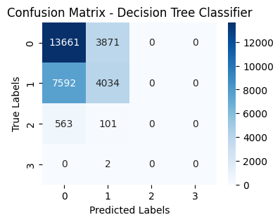

```python
dt_model = DecisionTreeClassifier(random_state=42)
dt_model.fit(X_train, y_train)
dt_pred = dt_model.predict(X_test)
dt_accuracy = accuracy_score(y_test, dt_pred)
dt_confusion = confusion_matrix(y_test, dt_pred)
model_results.append(("Decision Tree", dt_accuracy, dt_confusion))

print("Decision Tree Classifier:")
print("Model Prediction:", dt_pred)
print("Model Accuracy:", dt_accuracy)

plt.figure(figsize=(4, 3))
sns.heatmap(dt_confusion, annot=True, fmt="d", cmap="Blues")
plt.xlabel("Predicted Labels")
plt.ylabel("True Labels")
plt.title("Confusion Matrix - Decision Tree Classifier")
plt.show()
```

### Random Forest Classifier

```
Random Forest Classifier:
Model Prediction: [1 1 1 ... 1 1 1]
Model Accuracy: 0.5933141094420601
```

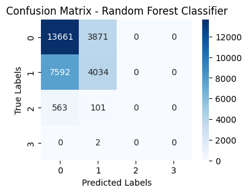

```python
rf_model = RandomForestClassifier(random_state=42)
rf_model.fit(X_train, y_train)
rf_pred = rf_model.predict(X_test)
rf_accuracy = accuracy_score(y_test, rf_pred)
rf_confusion = confusion_matrix(y_test, rf_pred)
model_results.append(("Random Forest", rf_accuracy, rf_confusion))

print("Random Forest Classifier:")
print("Model Prediction:", rf_pred)
print("Model Accuracy:", rf_accuracy)

plt.figure(figsize=(4, 3))
sns.heatmap(rf_confusion, annot=True, fmt="d", cmap="Blues")
plt.xlabel("Predicted Labels")
plt.ylabel("True Labels")
plt.title("Confusion Matrix - Random Forest Classifier")
plt.show()
```

### Logistic Regression

```
Logistic Regression:
Model Prediction: [1 1 1 ... 1 1 1]
Model Accuracy: 0.5826180257510729
```

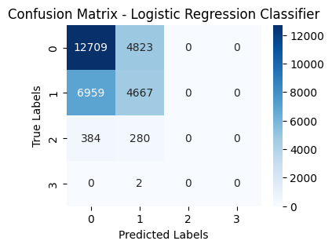

```python
lr_model = LogisticRegression(random_state=42)
lr_model.fit(X_train, y_train)
lr_pred = lr_model.predict(X_test)
lr_accuracy = accuracy_score(y_test, lr_pred)
lr_confusion = confusion_matrix(y_test, lr_pred)
model_results.append(("Logistic Regression", lr_accuracy, lr_confusion))

print("Logistic Regression:")
print("Model Prediction:", lr_pred)
print("Model Accuracy:", lr_accuracy)

plt.figure(figsize=(4, 3))
sns.heatmap(lr_confusion, annot=True, fmt="d", cmap="Blues")
plt.xlabel("Predicted Labels")
plt.ylabel("True Labels")
plt.title("Confusion Matrix - Logistic Regression Classifier")
plt.show()
```

### Support Vector Machine

```python
svm_model = SVC(random_state=42)
svm_model.fit(X_train, y_train)
svm_pred = svm_model.predict(X_test)
svm_accuracy = accuracy_score(y_test, svm_pred)
svm_confusion = confusion_matrix(y_test, svm_pred)
model_results.append(("SVM", svm_accuracy, svm_confusion))

print("Support Vector Machine:")
print("Model Prediction:", svm_pred)
print("Model Accuracy:", svm_accuracy)

plt.figure(figsize=(4, 3))
sns.heatmap(svm_confusion, annot=True, fmt="d", cmap="Blues")
plt.xlabel("Predicted Labels")
plt.ylabel("True Labels")
plt.title("Confusion Matrix - Support Vector Machine")
plt.show()
```

[output not shown]

[output not shown]

### Naive Bayes

```
Naive Bayes Classifier:
Model Prediction: [3 3 3 ... 2 1 3]
Model Accuracy: 0.3590732296137339
```

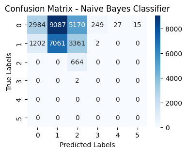

```python
nb_model = GaussianNB()
nb_model.fit(X_train, y_train)
nb_pred = nb_model.predict(X_test)
nb_accuracy = accuracy_score(y_test, nb_pred)
nb_confusion = confusion_matrix(y_test, nb_pred)
model_results.append(("Naive Bayes", nb_accuracy, nb_confusion))

print("Naive Bayes Classifier:")
print("Model Prediction:", nb_pred)
print("Model Accuracy:", nb_accuracy)

plt.figure(figsize=(4, 3))
sns.heatmap(nb_confusion, annot=True, fmt="d", cmap="Blues")
plt.xlabel("Predicted Labels")
plt.ylabel("True Labels")
plt.title("Confusion Matrix - Naive Bayes Classifier")
plt.show()
```

### Bagging Ensemble (using Decision Tree as base)

```
Ensemble Model (Bagging):
Model Prediction: [1 1 1 ... 1 1 1]
Model Accuracy: 0.5922411480686696
```

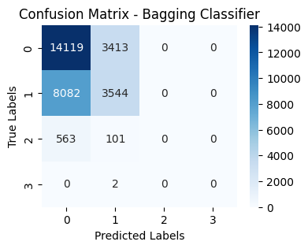

```python
bagging_model = BaggingClassifier(estimator=DecisionTreeClassifier(), random_state=42)
bagging_model.fit(X_train, y_train)
bagging_pred = bagging_model.predict(X_test)
bagging_accuracy = accuracy_score(y_test, bagging_pred)
bagging_confusion = confusion_matrix(y_test, bagging_pred)
model_results.append(("Bagging (Decision Tree)", bagging_accuracy, bagging_confusion))

print("Ensemble Model (Bagging):")
print("Model Prediction:", bagging_pred)
print("Model Accuracy:", bagging_accuracy)

plt.figure(figsize=(4, 3))
sns.heatmap(bagging_confusion, annot=True, fmt="d", cmap="Blues")
plt.xlabel("Predicted Labels")
plt.ylabel("True Labels")
plt.title("Confusion Matrix - Bagging Classifier")
plt.show()
```

### Voting Ensemble (using multiple models)

```
Ensemble Model (Voting):
Model Prediction: [1 1 1 ... 1 1 1]
Model Accuracy: 0.5887540236051502
```

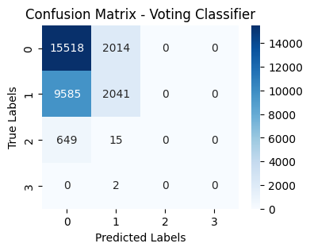

```python
voting_model = VotingClassifier(estimators=[
    ('lr', LogisticRegression()),
    ('rf', RandomForestClassifier()),
    ('svc', SVC(probability=True))
], voting='soft')
voting_model.fit(X_train, y_train)
voting_pred = voting_model.predict(X_test)
voting_accuracy = accuracy_score(y_test, voting_pred)
voting_confusion = confusion_matrix(y_test, voting_pred)
model_results.append(("Voting Ensemble", voting_accuracy, voting_confusion))

print("Ensemble Model (Voting):")
print("Model Prediction:", voting_pred)
print("Model Accuracy:", voting_accuracy)

plt.figure(figsize=(4, 3))
sns.heatmap(voting_confusion, annot=True, fmt="d", cmap="Blues")
plt.xlabel("Predicted Labels")
plt.ylabel("True Labels")
plt.title("Confusion Matrix - Voting Classifier")
```

### Compile results

```python
results_df = pd.DataFrame(model_results, columns=["Model", "Accuracy", "Confusion Matrix"])
results_df.sort_values(by="Accuracy", ascending=False)
```

|  | Model | Accuracy | Confusion Matrix |
| --- | --- | --- | --- |
| 0 | Decision Tree | 0.593314 | [[13661, 3871, 0, 0], [7592, 4034, 0, 0], [563... |
| 1 | Decision Tree | 0.593314 | [[13661, 3871, 0, 0], [7592, 4034, 0, 0], [563... |
| 2 | Decision Tree | 0.593314 | [[13661, 3871, 0, 0], [7592, 4034, 0, 0], [563... |
| 3 | Decision Tree | 0.593314 | [[13661, 3871, 0, 0], [7592, 4034, 0, 0], [563... |
| 4 | Decision Tree | 0.593314 | [[13661, 3871, 0, 0], [7592, 4034, 0, 0], [563... |
| 5 | Random Forest | 0.593314 | [[13661, 3871, 0, 0], [7592, 4034, 0, 0], [563... |
| 8 | Bagging (Decision Tree) | 0.592241 | [[14119, 3413, 0, 0], [8082, 3544, 0, 0], [563... |
| 9 | Voting Ensemble | 0.588754 | [[15518, 2014, 0, 0], [9585, 2041, 0, 0], [649... |
| 6 | Logistic Regression | 0.582618 | [[12709, 4823, 0, 0], [6959, 4667, 0, 0], [384... |
| 7 | Naive Bayes | 0.359073 | [[2984, 9087, 5170, 249, 27, 15], [1202, 7061,... |

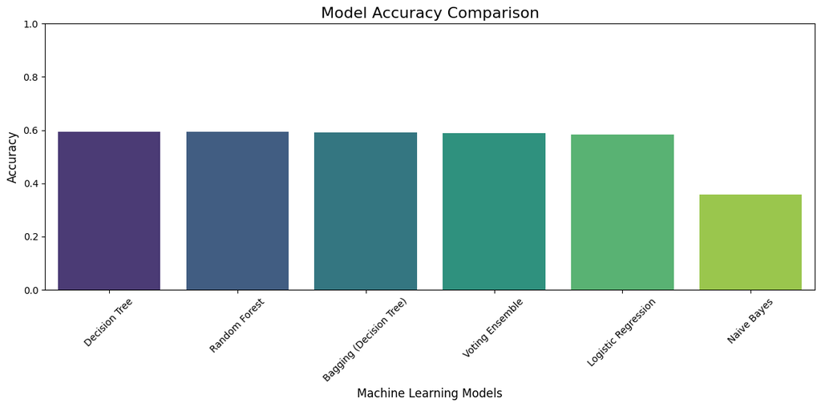

```python
plt.figure(figsize=(12, 6))
sns.barplot(data=results_df.sort_values(by="Accuracy", ascending=False), x="Model", y="Accuracy", palette="viridis")
plt.title("Model Accuracy Comparison", fontsize=16)
plt.xlabel("Machine Learning Models", fontsize=12)
plt.ylabel("Accuracy", fontsize=12)
plt.xticks(rotation=45)
plt.ylim(0, 1)  # Assuming accuracies are in [0, 1]
plt.tight_layout()
plt.show()
```

# Conclusion

## Model Performance

- **Decision Tree**:
  - Demonstrated consistent performance with an accuracy of 59.33%.
  - Relied on straightforward interpretability, making it a reliable baseline model.
- **Random Forest**:
  - Matched the Decision Tree in accuracy (59.33%) but offered better generalization by aggregating multiple trees.
- **Bagging (Decision Tree)**:
  - Slightly lower accuracy at 59.22%, showing the impact of variability in ensemble methods.
- **Voting Ensemble**:
  - Achieved 58.88% accuracy, combining multiple models to enhance decision-making.
  - Its slightly lower performance indicates that individual model contributions need fine-tuning.
- **Logistic Regression**:
  - Secured 58.26% accuracy, performing well for linear decision boundaries.
- **Naive Bayes**:
  - Had the lowest accuracy at 35.91%, showing its limitations with the given dataset's feature distributions.

## Final Thoughts

- While the Decision Tree and Random Forest showed comparable accuracy, their simplicity and efficiency make them valuable choices for initial analysis.
- The Voting Ensemble demonstrated the potential of combining multiple models, but its performance suggests room for optimization in model selection and weighting.
- Future work should explore hyperparameter optimization and advanced ensemble techniques to further improve accuracy and scalability.